# Spatial Visualization with R AKA maps

- The **[maps](https://cran.r-project.org/web/packages/maps/maps.pdf)** in R displays maps - projection code and larger maps are in other packages (mapproj and mapdata)
- **[ggmap](http://stat405.had.co.nz/ggmap.pdf)** enables visualisations by combining the layed grammar of graphics implementation of ggplot2 with spatial information of static maps from:
  - Google Maps
  - OpenStreetMap
  - Stamen Maps, or
  - CloudMade Maps
- Since ggplot2 is an implementation of the layered grammar of graphics. the coordinate system is fixed to the Mercator projection"
- **mapproj** adds more projections

```r
#load maps library
install.packages("maps")
library(maps)
#ggplot's map package
library (ggplot2)
install.packages("ggmap")
library(ggmap)
#map projection library
install.packages("mapproj")
install.packages("geosphere")
```

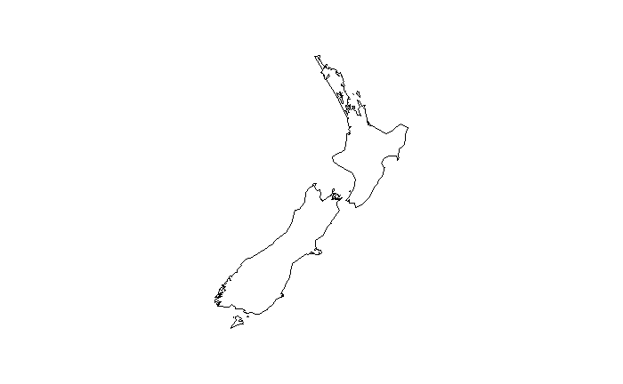

```r
#call a map
map("nz")
```

# Defining locations

Locations can be defined by:

1. Location or address
2. Logitude and Latitude
3. Defining an area bound by 4 points:
   - Lower left long
   - Lower left lat
   - upper right long
   - upper right lat

```r
#Method 1: Address/ location
my_location1<- "Melbourne"
my_location1
```

```
[1] "Melbourne"
```

```r
#Method 2: long/lat
my_location2<- c(lon=-95.3632715, lat=29.7632836)
my_location2
```

```
      lon       lat
-95.36327  29.76328
```

```r
#Method 3: bound area
myLocation3 <- c(-130, #lower left long
                 30, #lower left lat
                 -105, #upper right long
                 50) #upper right lat
myLocation3
```

```
[1] -130   30 -105   50
```

An important geo-feature for geo-rekated applications is getting **latitude** and **lonitude** for a given address.

- Previously could be done using `geocode` in `ggmap` with a Google Map API but now you need your own personal API key.
- .: Much easier to use `tmaptools`

```r
#install.packages("tmaptools")
library(tmaptools)
#get the coordiates and the "box"
geocode_OSM("Melbourne")
```

```
$query
[1] "Melbourne"

$coords
        x         y
144.96316 -37.81422

$bbox
     xmin      ymin      xmax      ymax
144.89709 -37.85067 144.99134 -37.77545
```

# Drawing a map of a defined location

Now we can map based on location. There are **four (4)** map sources with multiple map types:

1. **stamen**:
   - e.g.“terrain”, “toner”, “watercolour”, etc…
2. **Google**
   - API key required
   - “roadmap”, “terrain”, “satellite”, “hybrid”
3. **osm**:
   - open street map
4. **cloudmade**:
   - API key required
   - 1000s maps available

You can get the maps by trying `get_mapname` (e.g.: `get_googlemap`) Type in ?`get_mapname` to see what map types are availble!

[figure not shown]

```r
#define the location
my_location4 <- geocode_OSM("Melbourne")
#get the box vector from the results
bbox_vector <- as.vector(my_location4$bbox)
#get the bits of the vector to create the box!
bbox1 <- c(
  left = bbox_vector[1],
  bottom = bbox_vector[2],
  right   = bbox_vector[3],
  top  = bbox_vector[4])
#draw the map
#get the stamenmap maps
my_map <- get_stamenmap(

  #tell it what to map
  bbox = bbox1,

  #choose a map type
  maptype = "watercolor",

  #level of zoom
  zoom = 13

)
#plot the map
ggmap(my_map)
```

# Projecting a map

**Mercator** projections are:

- equally apaced straight meridians
- conformal
- straight compass courses

**[Albers](https://en.wikipedia.org/wiki/Albers_projection)** projections are:

- equal area
- conic
- uses two standard parallels

go to `?map` to find all the projection types.

### Projections and Gridlines

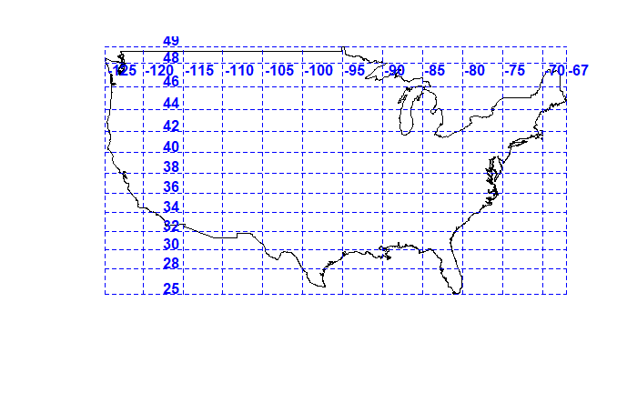

```r
require(mapproj)
#get map dta
#lat &amp, amp; lon for boundaries
m<- map("usa", plot = FALSE)
#try the mercator projection
map(m, projection = "mercator")
#draw grid lines
map.grid(m)
```

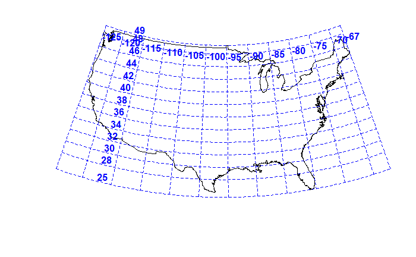

```r
#try the albers projection
#
map(m, projection = "albers",
    par = c(39, 45))
#draw grid lines
map.grid(m)
```

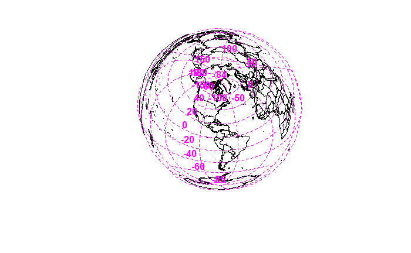

```r
#map the whole world
m <- map("world", plot = FALSE)
map(m, #what to map

    #projection type
    proj = "azequalarea",

    #choose where the "centre" is
    #An optional vector c(latitude,longitude,rotation) which describes where the "North Pole" should be when computing the projection.
    #Normally this is c(90,0), which is appropriate for cylindrical and conic projections.
    orient = c(41, -74, 0))
map.grid(m,

         #grid colour
         col = 6)
```

### Points on the graph

```r
map(m, #what to map

    #projection type
    proj = "orth",

    #choose where the "centre" is
    orient = c(41, -74, 0))
```

```
projection failed for some data
```

```r
#add grid lines
map.grid(
  m,
  col = 4,

  #number of equally spaced longitude and latitude lines
  nx = 5,
  ny = 6,

  label = FALSE,

  lty = 2
)
```

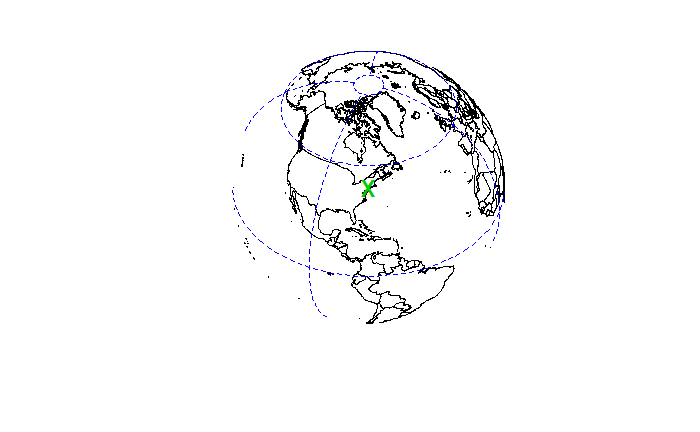

```r
#add some points
points(

  #tell is where to put the point
  #mapproject converts lonitude and latitude into projected coordinates
  mapproject(
    list(y = 41, #long
         x = -74)), #lat

    #colour of point
    col = 3,

    #what kind of mark
    pch = "x",

  #size of x
    cex = 2

)
```

### Labels

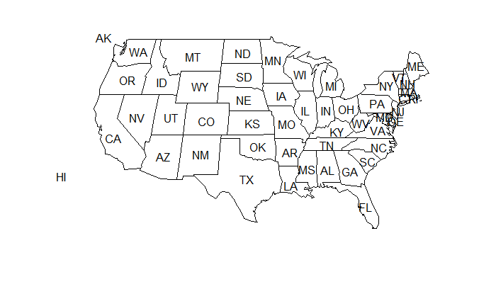

```r
map(
  "state",
  proj = "bonne",
  param = 0
)
#get state data
data(state)
text(
  mapproject(
    state.center),

  state.abb
)
```

# Using Quick Plot

`qmplot` is the ggmap equivalent to the ggplot2 function qplot and allows for the quick plotting of maps with data/models/etc.

Build a map using the crime dataset:

- Lightly cleaned Houston crime from January 2010 to August 2010 geocoded with Google Maps

```r
help(crime)
head(crime)
```

|  | time | date | hour | premise | offense | beat | block | street | type | suffix | number | month | day | location | address | lon | lat |
| --- | --- | --- | --- | --- | --- | --- | --- | --- | --- | --- | --- | --- | --- | --- | --- | --- | --- |
| 82729 | 2010-01-01 16:00:00 | 1/1/2010 | 0 | 18A | murder | 15E30 | 9600-9699 | marlive | ln | - | 1 | january | friday | apartment parking lot | 9650 marlive ln | -95.43739 | 29.67790 |
| 82730 | 2010-01-01 16:00:00 | 1/1/2010 | 0 | 13R | robbery | 13D10 | 4700-4799 | telephone | rd | - | 1 | january | friday | road / street / sidewalk | 4750 telephone rd | -95.29888 | 29.69171 |
| 82731 | 2010-01-01 16:00:00 | 1/1/2010 | 0 | 20R | aggravated assault | 16E20 | 5000-5099 | wickview | ln | - | 1 | january | friday | residence / house | 5050 wickview ln | -95.45586 | 29.59922 |
| 82732 | 2010-01-01 16:00:00 | 1/1/2010 | 0 | 20R | aggravated assault | 2A30 | 1000-1099 | ashland | st | - | 1 | january | friday | residence / house | 1050 ashland st | -95.40334 | 29.79024 |
| 82733 | 2010-01-01 16:00:00 | 1/1/2010 | 0 | 20A | aggravated assault | 14D20 | 8300-8399 | canyon |  | - | 1 | january | friday | apartment | 8350 canyon | -95.37791 | 29.67063 |
| 82734 | 2010-01-01 16:00:00 | 1/1/2010 | 0 | 20R | burglary | 18F60 | 9300-9399 | rowan | ln | - | 1 | january | friday | residence / house | 9350 rowan ln | -95.54830 | 29.70223 |

Plot the murders on a map

```
Using zoom = 11...
```

[figure not shown]

```r
#get the subset of data where the offence is murder
murder <- subset(crime,
              offense == "murder")
qmplot(
  #lonitude values
  x = lon,

  #latitude values
  y = lat,

  #data
  data = murder,

  #colour
  colour = I("red"),

  #size of data points
  size = I(3),

  #vector of the form c(number, color), where number is in [0, 1] and color is a character string indicating the color of the darken. 0 indicates no darkening, 1 indicates a black-out.
  #how dark the map is (??)
  darken = 0.3
)
```

# Chloropleth Maps

Plot a chloropleth map of unemployment rates in the US.

```r
help(unemp)
head(unemp)
```

|  | fips | pop | unemp |
| --- | --- | --- | --- |
| 1 | 1001 | 23288 | 9.7 |
| 2 | 1003 | 81706 | 9.1 |
| 3 | 1005 | 9703 | 13.4 |
| 4 | 1007 | 8475 | 12.1 |
| 5 | 1009 | 25306 | 9.9 |
| 6 | 1011 | 3527 | 16.4 |

```r
help("county.fips")
head(county.fips)
```

|  | fips | polyname |
| --- | --- | --- |
| 1 | 1001 | alabama,autauga |
| 2 | 1003 | alabama,baldwin |
| 3 | 1005 | alabama,barbour |
| 4 | 1007 | alabama,bibb |
| 5 | 1009 | alabama,blount |
| 6 | 1011 | alabama,bullock |

```r
#what data to use
data("unemp")
#define the intervals for the chloromap
Intervals <- as.numeric(

  #Cut uses the base function cut to classify the values of a Raster* object according to which interval they fall in.
  cut(
    #which column needs to be turned into class/ categoies
    unemp$unemp,

    #set the categories
    #in this case it will be ("<2%","2-4%","4-6%","6-8%","8-10%",">10%")
    #first number in inclusive, second number is not
    c(0,2,4,6,8,10,100)
  )
)
#match unemployment data to map regions using the fips codes
data("county.fips")
Matches <- Intervals[

  #will match the first one to the second one
  match(
    #which column to look up
    county.fips$fips,

    unemp$fips
  )
]
#DRAW THE MAP
#choose the colours for each interval
colors <- c("#ffffd4","#fee391","#fec44f","#fe9929","#d95f0e","#993404")
map("county", #what to map: county data

    #match level to colour
    col = colors[Matches],

    #colour in the map
    fill = TRUE,

    resolution = 0,

    #line type around county areas
    lty = 0,

    #type of projection
    projection = "polyconic"


)
#add state boundries layer
map("state",

    #colour
    col = "black",

    #dont colour in
    fill = FALSE,

    #add to previous map
    add = TRUE,

    #type of line
    lty = 1,

    #line thikness
    lwd = 0.3,

    projection = "polyconic")
```

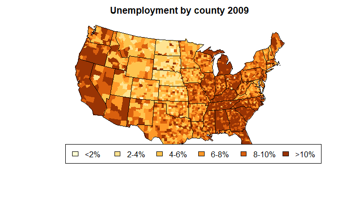

```r
#add a title
title("Unemployment by county 2009")
#add a legend
Legend <- c("<2%", "2-4%","4-6%","6-8%","8-10%",">10%")
legend("bottomright",
       Legend,
       horiz = TRUE,
       fill = colors)
```

# Flow Map

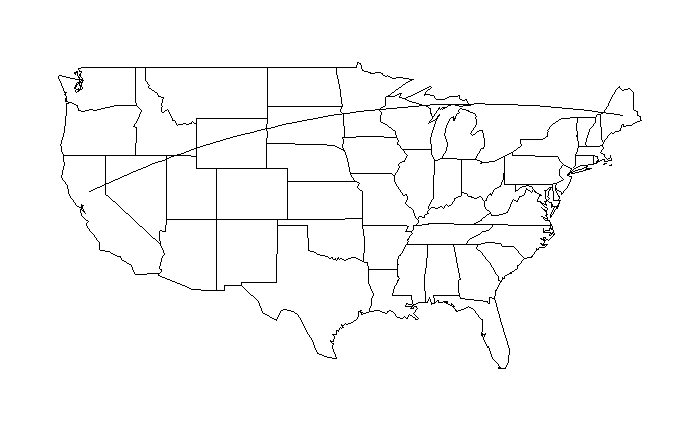

```r
library(geosphere)
map("state")
lat_ca <- 39.164141
lon_ca <- -121.640625

lat_me <- 45.213004
lon_me <- -68.906250
inter <- gcIntermediate( #Get intermediate points (way points) between the two locations with longitude/latitude coordinates. gcIntermediate is based on a spherical model of the earth and internally uses distCosine.

  #point 1
  c(lon_ca, lat_ca),

  #point 2
  c(lon_me, lat_me),

  #number of intermediate points
  n = 50,

  #add p1 and p2 to the result?
  addStartEnd = TRUE
)
#add the line on top of the map
lines(inter)
```

Example: plotting american airline (AA) flights

```r
#load csv data from website
airports <- read.csv("http://datasets.flowingdata.com/tuts/maparcs/airports.csv", header = TRUE)
flights <- read.csv("http://datasets.flowingdata.com/tuts/maparcs/flights.csv", header = TRUE, as.is = TRUE)

head(airports)
```

|  | iata | airport | city | state | country | lat | long |
| --- | --- | --- | --- | --- | --- | --- | --- |
| 1 | 00M | Thigpen | Bay Springs | MS | USA | 31.95376 | -89.23450 |
| 2 | 00R | Livingston Municipal | Livingston | TX | USA | 30.68586 | -95.01793 |
| 3 | 00V | Meadow Lake | Colorado Springs | CO | USA | 38.94575 | -104.56989 |
| 4 | 01G | Perry-Warsaw | Perry | NY | USA | 42.74135 | -78.05208 |
| 5 | 01J | Hilliard Airpark | Hilliard | FL | USA | 30.68801 | -81.90594 |
| 6 | 01M | Tishomingo County | Belmont | MS | USA | 34.49167 | -88.20111 |

```r
head(flights)
```

|  | airline | airport1 | airport2 | cnt |
| --- | --- | --- | --- | --- |
| 1 | AA | DFW | SJU | 120 |
| 2 | AA | MSP | DFW | 326 |
| 3 | AA | LGA | ORD | 860 |
| 4 | AA | TPA | JFK | 56 |
| 5 | AA | STT | BOS | 44 |
| 6 | AA | PHX | DFW | 550 |

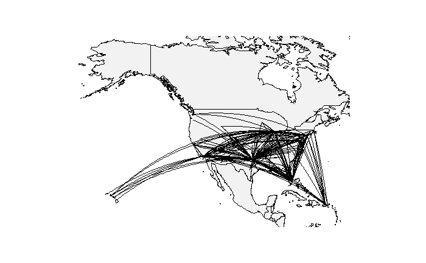

```r
# create a world map and limited it to around US areas.
xlim <- c(-171.738281, -56.601563)
ylim <- c(12.039321, 71.856229)
#draw the map
map(
  "world",

  #map colour
  col = "#f2f2f2",

  fill = TRUE,

  #background colour
  bg  = "white",

  #link width
  lwd = 0.05,

  xlim = xlim,
  ylim = ylim

)
#plot the flights
#get AA flights only
flights_AA <- flights[flights$airline == "AA",]
#for each row in the flights database we need to add a line to the graph
for (j in 1:length(flights_AA$airline)){


  #airport 1 (point 1)
  #get the airport from the first row of the flights and return the long and lat where the iata (abbrev) matches it from the aiport database
  air1 <- airports[airports$iata == flights_AA[j,]$airport1,]

  #same for airport 2
  air2 <- airports[airports$iata == flights_AA[j,]$airport2,]

  inter <- gcIntermediate(

    #point 1
    c(air1[1,]$long,
      air1[1,]$lat),

    #point 2
    c(air2[1,]$long,
      air2[1,]$lat),

    n = 100,

    addStartEnd = TRUE
  )

  #add the lines
  lines(inter,
        col = "black",
        lwd = 0.8)

}
```